# world_map_plots

## R Markdown

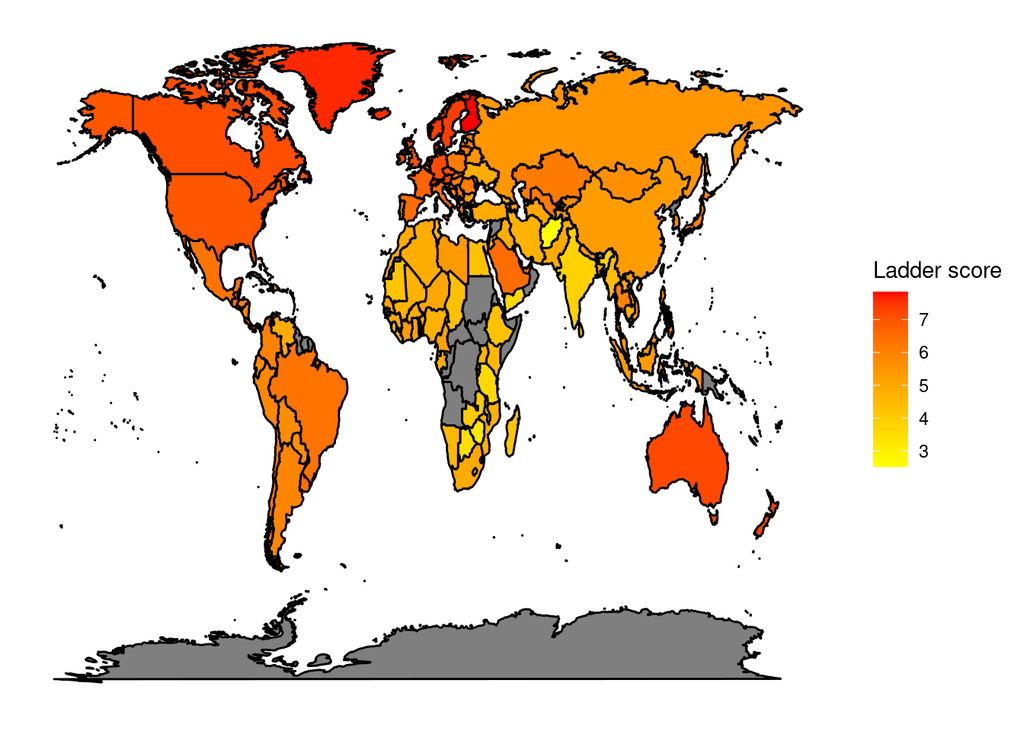

```r
world_happiness <- readr::read_csv("https://raw.githubusercontent.com/illinois-stat447/fa21-prj-shiyuan8-sw20-zihanz12-zl32/master/data/world-happiness-report-2020.csv?token=AKH4K3ZTOOQABV5NEUJJGQLBXJOCQ",show_col_types = FALSE)

world_happiness$region = world_happiness$`Country name`

world_happiness = world_happiness |>
  mutate(region = replace(region, region == 'USA', 'United States'))

world_happiness = world_happiness |>
  mutate(region = replace(region, region == 'Democratic Republic of the Congo', 'Democratic Republic of Congo'))

world_happiness = world_happiness |>
  mutate(region = replace(region, region == 'UK', 'United Kingdom'))

world_happiness = world_happiness |>
  mutate(region = replace(region, region == 'Greenland', 'Denmark'))


mapdata <- map_data("world") ##ggplot2
# View(mapdata)

new_mapdata = mapdata |>
  mutate(region = replace(region, region == 'USA', 'United States'))

new_mapdata = new_mapdata |>
  mutate(region = replace(region, region == 'Democratic Republic of the Congo', 'Democratic Republic of Congo'))

new_mapdata = new_mapdata |>
  mutate(region = replace(region, region == 'UK', 'United Kingdom'))

new_mapdata = new_mapdata |>
  mutate(region = replace(region, region == 'Greenland', 'Denmark'))


mapdata_world_happiness <- left_join(new_mapdata, world_happiness, by="region")
# View(mapdata)

#remove na
# mapdata1<-mapdata |> filter(!is.na(mapdata$`Ladder score`))
# View(mapdata1)

map1<-ggplot(mapdata_world_happiness, aes( x = long, y = lat, group=group)) +
  geom_polygon(aes(fill = `Ladder score`), color = "black")

map2 <- map1 + scale_fill_gradient(name = "Ladder score", low = "yellow", high =  "red", na.value = "grey50")+
  theme(axis.text.x = element_blank(),
        axis.text.y = element_blank(),
        axis.ticks = element_blank(),
        axis.title.y=element_blank(),
        axis.title.x=element_blank(),
        rect = element_blank())
map2
```

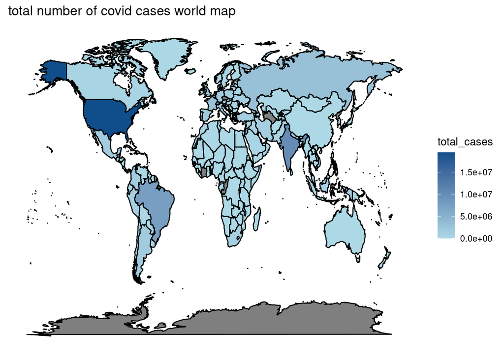

```r
covid_data_2020 = readr::read_csv("https://raw.githubusercontent.com/illinois-stat447/fa21-prj-shiyuan8-sw20-zihanz12-zl32/master/data/covid_2020_total.csv?token=AKH4K33CEG4UJXXTNV7LLFLBXJTT2", show_col_types = FALSE)
#remove first index column

covid_data_2020 <- covid_data_2020[ -c(1) ]
# View(covid_data_2020)
covid_data_2020$region = covid_data_2020$`country`


mapdata <- map_data("world") ##ggplot2
# View(mapdata)

new_mapdata = mapdata |>
  mutate(region = replace(region, region == 'USA', 'United States'))

new_mapdata = new_mapdata |>
  mutate(region = replace(region, region == 'Democratic Republic of the Congo', 'Democratic Republic of Congo'))

new_mapdata = new_mapdata |>
  mutate(region = replace(region, region == 'UK', 'United Kingdom'))

new_mapdata = new_mapdata |>
  mutate(region = replace(region, region == 'Greenland', 'Denmark'))


# unique(new_mapdata[c("region")])

mapdata_and_covid_2020 <- left_join(new_mapdata, covid_data_2020, by="region")
# View(mapdata_and_covid_2020)



# View(unique(mapdata_and_covid_2020[c("region")]))

#remove na
# mapdata_and_covid_2020<-mapdata_and_covid_2020 |> filter(!is.na(mapdata_and_covid_2020$total_cases))
# View(mapdata_and_covid_2020)

map3<-ggplot(mapdata_and_covid_2020, aes( x = long, y = lat, group=group)) +
  geom_polygon(aes(fill = total_cases), color = "black") +
  ggtitle("total number of covid cases world map")

map4 <- map3 + scale_fill_gradient(name = "total_cases", low = "light blue", high =  "dodgerblue4", na.value = "grey50")+
  theme(axis.text.x = element_blank(),
        axis.text.y = element_blank(),
        axis.ticks = element_blank(),
        axis.title.y=element_blank(),
        axis.title.x=element_blank(),
        rect = element_blank())
map4
```

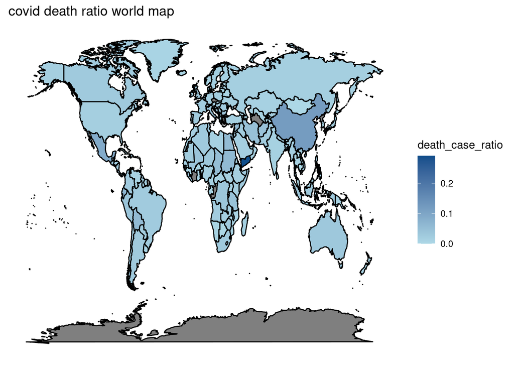

```r
map5<-ggplot(mapdata_and_covid_2020, aes( x = long, y = lat, group=group)) +
  geom_polygon(aes(fill = death_case_ratio), color = "black")+
  ggtitle("covid death ratio world map")

map6 <- map5 + scale_fill_gradient(name = "death_case_ratio", low = "light blue", high =  "dodgerblue4", na.value = "grey50")+
  theme(axis.text.x = element_blank(),
        axis.text.y = element_blank(),
        axis.ticks = element_blank(),
        axis.title.y=element_blank(),
        axis.title.x=element_blank(),
        rect = element_blank())
map6
```

```r
# require(gridExtra)
#
# grid.arrange(map6, map5, widths = c(10,10), ncol=2)
```

From the **total number of covid cases world map**, we can observe that countries such as United States, India and Brazil have very high number of covid infection rate. On the other hand, countries like China have lower covid infection rate.

However, from the **covid death ratio world map**, we can observe that countries like United States, India and Brazil, which have very high number of covid infection rate, now have a relatively lower death ratio. This interesting phenomenon could be due to effective vaccination or unreported/misrecorded death rate.

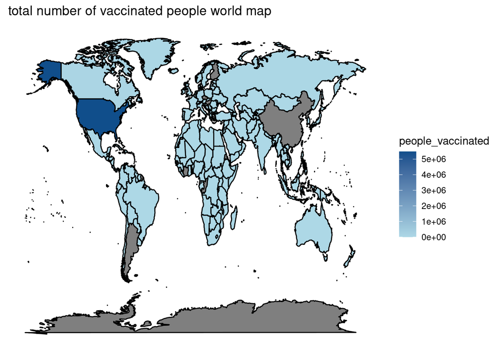

```r
vaccination_data_2020 <- readr::read_csv("https://raw.githubusercontent.com/illinois-stat447/fa21-prj-shiyuan8-sw20-zihanz12-zl32/master/vaccination/data/world_vacci_data_2020.csv?token=AKH4K37S6CBXCEW544XX6K3BXJ4CK",show_col_types = FALSE)
vaccination_data_2020$region = vaccination_data_2020$`location`

mapdata_and_vaccination_2020 <- left_join(new_mapdata, vaccination_data_2020, by="region")

map5<-ggplot(mapdata_and_vaccination_2020, aes( x = long, y = lat, group=group)) +
  geom_polygon(aes(fill = people_vaccinated), color = "black")+
  ggtitle("total number of vaccinated people world map")

map6 <- map5 + scale_fill_gradient(name = "people_vaccinated", low = "light blue", high =  "dodgerblue4", na.value = "grey50")+
  theme(axis.text.x = element_blank(),
        axis.text.y = element_blank(),
        axis.ticks = element_blank(),
        axis.title.y=element_blank(),
        axis.title.x=element_blank(),
        rect = element_blank())
map6
```

From the **total number of vaccinated people world map**, we can observe that countries such as United States have very high vaccination rate. This justifies my previous assumption about United State’s low death rate ratio. On the other hand, vaccination information is not provided for countries like China in the raw data we find.

To examine the whether the differences between the covid data, vaccination data and world happiness data are statistically significant, we wish to conduct ANOVA.